# Board Games Hero

Ali Ezzat

July 22, 2018

## Overview

This page contains a few preliminary visualizations using the dataset obtained from the following link: https://www.kaggle.com/gabrio/board-games-dataset

The final version of this project is intended to have the following features:

- Faciltated browsing of board games by category, game mechanic, designer, year of release and more
- Recommender system for suggesting your next board game based on preferences and previous game purchase history
- Facilitated analyses to assist board game enthusiasts on making reports on the current state of affairs in board gaming as well as to help board game designers identify gaps in the market for their next game.

## Getting Started

Let’s start with loading the necessary packages and reading the information stored in the board games dataset.

```r
library(tidyverse)
library(RSQLite)

# connect to the sqlite file
sqlite <- dbDriver("SQLite")
bggdb <- dbConnect(sqlite,"database.sqlite")

# show tables in this database
dbListTables(bggdb)
```

```
## [1] "BoardGames"               "bgg.ldaOut.top.documents"
## [3] "bgg.ldaOut.top.terms"     "bgg.ldaOut.topics"
## [5] "bgg.topics"
```

We are only interested in the `BoardGames` table for now, so…

```r
# store contents of table, "BoardGames", into the data frame, "bg_table"
bg_table <- dbReadTable(bggdb, "BoardGames")

# show column names
colnames(bg_table)
```

```
##  [1] "row_names"
##  [2] "game.id"
##  [3] "game.type"
##  [4] "details.description"
##  [5] "details.image"
##  [6] "details.maxplayers"
##  [7] "details.maxplaytime"
##  [8] "details.minage"
##  [9] "details.minplayers"
## [10] "details.minplaytime"
## [11] "details.name"
## [12] "details.playingtime"
## [13] "details.thumbnail"
## [14] "details.yearpublished"
## [15] "attributes.boardgameartist"
```

[output cut: 66 more lines]

There are seemingly irrelevant columns (or fields) at the end of the list. Specifically, columns 69 through 81 seem to mainly relate to video games. Therefore, we shall remove them before moving on.

```r
# keep columns 1 to 68 and discard the rest
bg_table <- bg_table[,1:68]
```

## Plot #1

The first plot is of the different categories of board games and the numbers of games created in each of them. In addition, each category has its games divided into two sections: (i) those whose average user ratings are equal to above 7 (out of 10) and (ii) those that are below 7. This shows how easy/difficult to find a good game in each of these categories. In this plot, we restrict ourselves to games released from the year 2000 onward.

In preparation for the plot, a bit of data wrangling is required. The main reason is that board game categories are not mutually exclusive (that is, they overlap).

```r
# keep only board games that have a category assigned
bg_table <-
  bg_table %>%
  filter(!is.na(attributes.boardgamecategory) & details.yearpublished >= 2000) %>%
  mutate(highly_rated = (stats.average >= 7))

# show the categories of the first 50 board games
head(bg_table$attributes.boardgamecategory, 50)
```

```
##  [1] "Bluffing,Card Game"
##  [2] "Bluffing,Political"
##  [3] "Bluffing,Card Game,City Building,Fantasy,Medieval"
##  [4] "Medieval"
##  [5] "Fantasy,Mythology,Print & Play,Wargame"
##  [6] "Medieval,Territory Building"
##  [7] "Arabian,Bluffing,Fantasy,Medieval"
##  [8] "Pirates"
##  [9] "Action / Dexterity,Card Game"
## [10] "Card Game"
## [11] "Card Game"
## [12] "Exploration"
## [13] "Animals,Nautical"
## [14] "Economic,Real-time,Renaissance"
## [15] "Card Game,Fantasy,Maze"
```

[output cut: 35 more lines]

At this point, we want to create a corpus (and, subsequently, a document-term matrix) of all unique board game categories. We shall do so using the [quanteda](https://cran.r-project.org/web/packages/quanteda/) package. However, the quanteda is only able to distinguish the different categories if they are separated by spaces, which is why we will do as follows.

```r
# deal with all occurrences of '&', '/'
bg_table$attributes.boardgamecategory <-
  gsub(bg_table$attributes.boardgamecategory, pattern=' & ',    replacement='_', fixed=TRUE)
bg_table$attributes.boardgamecategory <-
  gsub(bg_table$attributes.boardgamecategory, pattern=' / ',    replacement='_', fixed=TRUE)
bg_table$attributes.boardgamecategory <-
  gsub(bg_table$attributes.boardgamecategory, pattern='/',      replacement='_', fixed=TRUE)


# replace spaces with underscores to merge multi-word categories
bg_table$attributes.boardgamecategory <-
  gsub(bg_table$attributes.boardgamecategory, pattern=' ', replacement='_', fixed=TRUE)

# replace all occurrences of ',' with spaces to separate between categories
bg_table$attributes.boardgamecategory <-
  gsub(bg_table$attributes.boardgamecategory, pattern=',', replacement=' ', fixed=TRUE)


head(bg_table$attributes.boardgamecategory, 50)
```

```
##  [1] "Bluffing Card_Game"
##  [2] "Bluffing Political"
##  [3] "Bluffing Card_Game City_Building Fantasy Medieval"
##  [4] "Medieval"
##  [5] "Fantasy Mythology Print_Play Wargame"
##  [6] "Medieval Territory_Building"
##  [7] "Arabian Bluffing Fantasy Medieval"
##  [8] "Pirates"
##  [9] "Action_Dexterity Card_Game"
## [10] "Card_Game"
## [11] "Card_Game"
## [12] "Exploration"
## [13] "Animals Nautical"
## [14] "Economic Real-time Renaissance"
## [15] "Card_Game Fantasy Maze"
```

[output cut: 35 more lines]

So far so good. Let’s create the corpus and the document-term matrix.

```r
library (quanteda)

# create the corpus object from the industry_of_company column
mycorpus <- corpus(bg_table$attributes.boardgamecategory)

# generate the DTM using the formed corpus
dfm_bgcategories <- dfm(mycorpus,               # the corpus to generate the DTM from
                        tolower = FALSE)        # data is already lowercase

# observe the 'terms' of the DTM
sort(colnames(dfm_bgcategories))
```

```
##  [1] "Abstract_Strategy"          "Action_Dexterity"
##  [3] "Adventure"                  "Age_of_Reason"
##  [5] "American_Civil_War"         "American_Indian_Wars"
##  [7] "American_Revolutionary_War" "American_West"
##  [9] "Ancient"                    "Animals"
## [11] "Arabian"                    "Aviation_Flight"
## [13] "Bluffing"                   "Book"
## [15] "Card_Game"                  "Children's_Game"
## [17] "City_Building"              "Civil_War"
## [19] "Civilization"               "Collectible_Components"
## [21] "Comic_Book_Strip"           "Deduction"
## [23] "Dice"                       "Economic"
## [25] "Educational"                "Electronic"
## [27] "Environmental"              "Expansion_for_Base-game"
## [29] "Exploration"                "Fan_Expansion"
```

[output cut: 27 more lines]

We have 84 distinct board game categories. Let’s show the plot we had in mind from the beginning. Note that we will do some handpicking because there are too many categories to fit in the visualization.

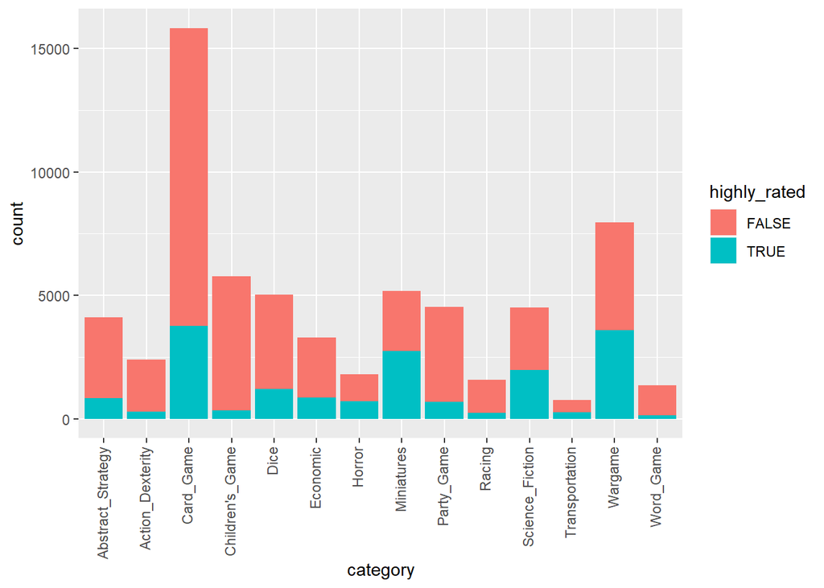

```r
dfm_bgcategories %>%
  convert(to='data.frame') %>%
  cbind(highly_rated=bg_table$highly_rated) %>%
  gather("category","n",2:85) %>%
  select(category,highly_rated,n) %>%
  group_by(category,highly_rated) %>%
  summarise(count = sum(n)) %>%
  filter(category %in% c("Abstract_Strategy",
                         "Action_Dexterity",
                         "Children's_Game",
                         "Card_Game",
                         "Economic",
                         "Dice",
                         "Horror",
                         "Racing",
                         "Party_Game",
                         "Science_Fiction",
                         "Transportation",
                         "Miniatures",
                         "Word_Game",
                         "Wargame")) %>%
  ggplot(aes(x = category, y = count, fill = highly_rated)) + # X: category, Y: #games in category
  geom_bar(stat="identity") +                                 #
  theme(axis.text.x = element_text(angle = 90,                # rotate orientation of x-axis labels
                                   vjust = 0.3,               # top-align x-axis labels
                                   hjust = 1))                # right-align x-axis labels
```

It is not very surprising that card games is the category with most the games released, but observing that the wargames category has the second most number of games was kind of unexpected. Apparently, there are not many *good* games around. On the other hand, the criterion that we chose for specifying a *good* game was a bit stringent.

On to our next plot!

## Plot #2

The first plot is of the different board game designers and what the user ratings are like. So let’s get to it.

We’ll first reload the `BoardGames` table into `bg_table` and keep those board games that have a designer assigned. Again, we focus on games released from the year 2000 onward.

```r
# store contents of table, "BoardGames", into the data frame, "bg_table"
bg_table <- dbReadTable(bggdb, "BoardGames")

# keep columns 1 to 68 and discard the rest
bg_table <- bg_table[,1:68]

# keep only board games that have a designer assigned
bg_table <-
  bg_table %>%
  filter(!is.na(attributes.boardgamedesigner) & details.yearpublished >= 2000)

# show the categories of the first 50 board game designers
head(bg_table$attributes.boardgamedesigner, 50)
```

```
##  [1] "Bruno Faidutti"
##  [2] "Reiner Knizia"
##  [3] "Bruno Faidutti"
##  [4] "Leo Colovini"
##  [5] "Angelo Porazzi"
##  [6] "Michael Schacht"
##  [7] "Richard Breese"
##  [8] "Alan R. Moon,Aaron Weissblum"
##  [9] "Alex Randolph"
## [10] "Reiner Knizia"
## [11] "Christine Lehmann,Wolfgang A. Lehmann"
## [12] "Reinhard Staupe"
## [13] "Patrick Dolan"
## [14] "Patrick Folan"
## [15] "Reiner Knizia"
```

[output cut: 35 more lines]

So, *how many board game designers are there?* We will focus on games having a single designer for now.

```r
bg_table %>%
  filter(!grepl(',',attributes.boardgamedesigner,fixed=TRUE)) %>%
  select(attributes.boardgamedesigner) %>%
  unique() %>%
  unlist() %>%
  length()
```

```
## [1] 9980
```

There have been so many board game designers over the years. Let’s have a look at those with a high average rating over 10 or more games.

```r
bg_table_single_designer <-
  bg_table %>%
  filter(!grepl(',',attributes.boardgamedesigner,fixed=TRUE)) %>%
  filter(!grepl('(',attributes.boardgamedesigner,fixed=TRUE)) %>%
  select(attributes.boardgamedesigner, stats.average)

# get names of designers with 10 or more games and an average game rating of at least 7.5
selected_designers <-
  bg_table_single_designer %>%
  group_by(attributes.boardgamedesigner) %>%
  summarise(avg_bg_rating = mean(stats.average), num_games=n()) %>%
  filter(avg_bg_rating>7.5 & num_games>=10) %>%
  select(attributes.boardgamedesigner)

# show selected designers
selected_designers
```

```
## # A tibble: 22 x 1
##    attributes.boardgamedesigner
##    <chr>
##  1 Adam Smith
##  2 Benoit Vogt
##  3 Caleb Grace
##  4 Colby Dauch
##  5 Corey Konieczka
##  6 Dean Essig
##  7 Don Eskridge
##  8 Erik Kjerland
##  9 Hermann Luttmann
## 10 Isaias Vallejo
## # ... with 12 more rows
```

Let’s view them in a plot…

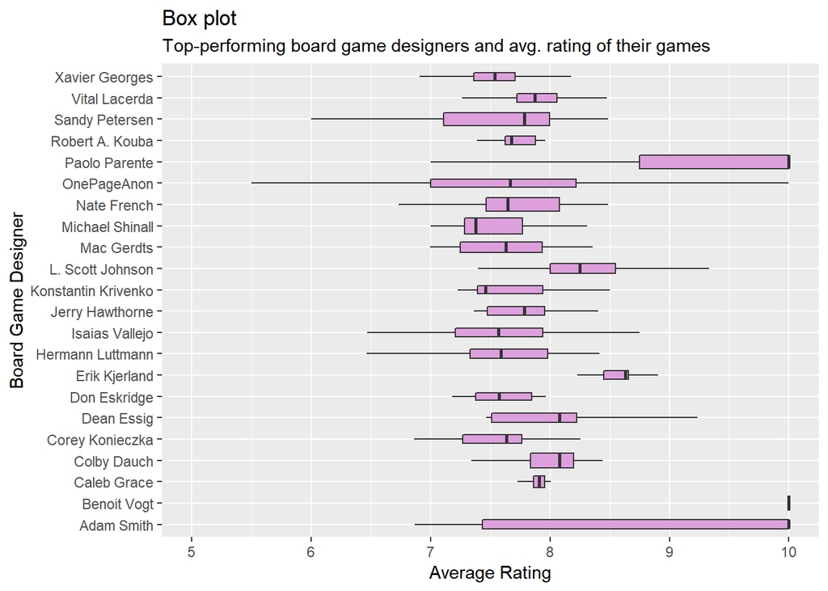

```r
bg_table_single_designer %>%
  filter(attributes.boardgamedesigner %in% unlist(selected_designers)) %>%
  ggplot(aes(attributes.boardgamedesigner, stats.average)) +
  geom_boxplot(varwidth=TRUE, fill="plum", outlier.shape = NA) +
  labs(title="Box plot",
       subtitle="Top-performing board game designers and avg. rating of their games",
       x="Board Game Designer",
       y="Average Rating") +
  coord_flip() +
  ylim(5,10)
```